# Lunchtime #5: Pillow

## Why using Python for image processing?

- Easy automation of image processing (compared to GUIs)
- High-Level interfaces usable without very deep knowledge of image formats
- Easy integration with other Python-based tools for e.g.
  - Image Analysis
  - Web Scraping
  - ML/AI

## Pillow is *the friendly fork* of PIL, the Python Imaging Library:

- PIL is/was the state-of-the-art library for image processing in Python
- Had several issues caused by the project maintenance:
  - Compatibility issues with standard installation procedures
  - Missing open community work for issues, contributions etc.
  - Sustainability issues due to missing Continuous Integration
- Pillow has stepped in, PIL had its last release in 2009

## The Basics: Loading an image

We import `Image` from the `PIL` package:

```python
from PIL import Image
```

We can open an image from disk by using `open`:

```python
if "google.colab" in str(get_ipython()):
    !wget https://ssciwr.github.io/lunch-time-python/lunchtime5/thingstaette.png -q
img = Image.open("thingstaette.png")
```

The image is represented using the `Image` class from PIL (or one of its specialized subclasses). Images can be created by loading from file, from other images or programmatically.

The `img` object can be queried for a number of metadata fields of the image:

```python
img.format
```

```
'PNG'
```

```python
img.size
```

```
(856, 652)
```

```python
img.width, img.height
```

```
(856, 652)
```

```python
img.mode
```

```
'RGBA'
```

```python
img.getbands()
```

```
('R', 'G', 'B', 'A')
```

## Visualizing images in Jupyter

To display the image directly in Jupyter notebooks, we can use the `IPython`'s rich display system. Alternatively, `img.show()` can open the image in an external viewer.

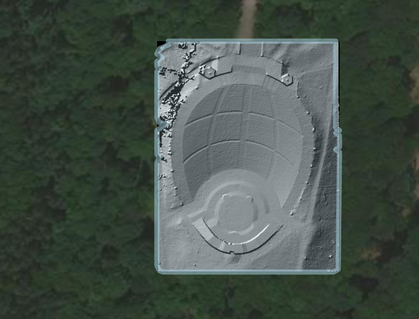

```python
img
```

## Modifying images

Image modifications operate on one image and return a new image which is a copy of the original with the applied modifications. This is common (good) practice in object-oriented programming.

## Cropping

```python
cropped = img.crop([330, 100, 650, 550])
```

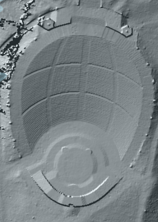

```python
cropped
```

## Resizing

```python
resized = cropped.reduce(2)
# resized = cropped.resize((150, 100))
```

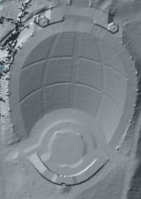

```python
resized
```

## Transforming

```python
rotated = resized.rotate(180)
```

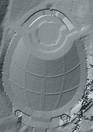

```python
rotated
```

## Applying filters

```python
from PIL import ImageFilter
```

```python
blurred = rotated.filter(ImageFilter.BLUR)
```

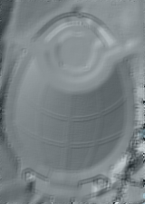

```python
blurred
```

## Merging

Merging is done as an in-place operation on the `Image` object:

```python
img.paste(rotated, (100, 100))
```

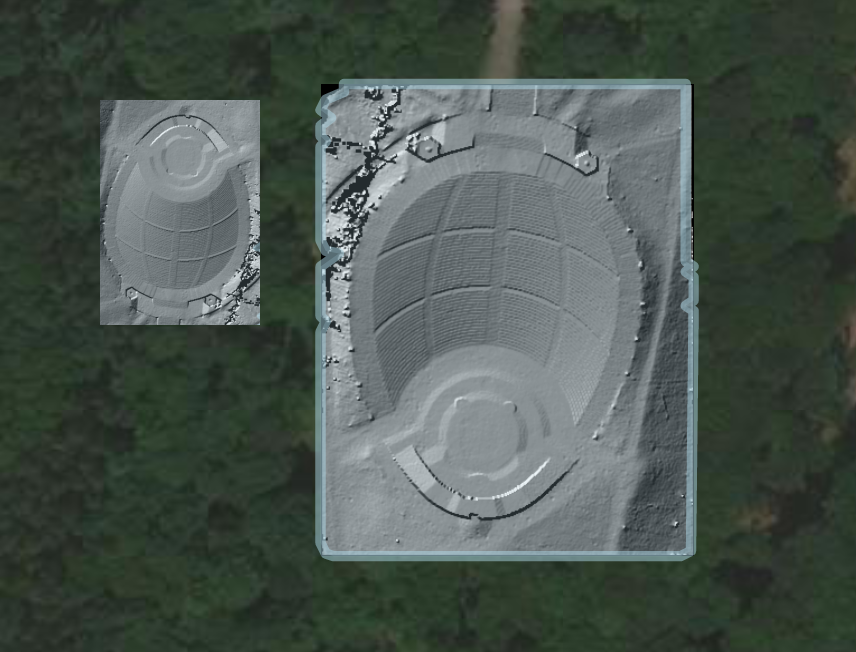

```python
img
```

## Saving Images

After successful transformation, we can save the result.

- Output format deduced from given file extension
- Alternatively passed explicitly
- Format conversion implemented by `PIL`
- Some formats require certain conditions on the data

```python
converted = img.convert("RGB")
```

```python
converted.getbands()
```

```
('R', 'G', 'B')
```

```python
converted.save("final.jpg")
```

## Further information

Pillow has much more functionality than shown here today, check the examples and references in its documentation:

https://pillow.readthedocs.io

Thanks for joining!